# Reproducible Research: Peer Assessment 1

## Loading and preprocessing the data

```r
rawData <- read.csv("/Users/Fang/Desktop/Data_Science/Coursera/Reproducible_Research/activity.csv")
```

```r
library(dplyr)
## transform data_frame data to tbl_frame data which can be applied by group_by function
groupData <- tbl_df(rawData)
## remove the original data frame rawData
rm(rawData)
## group data by date
day_groupData <- group_by(groupData, date)
## get total steps for each day
total_steps <- summarise(day_groupData, total.steps = sum(steps,na.rm  = TRUE))
## names(total_steps) = c("date", "total.steps")
```

## What is mean total number of steps taken per day?

- **Make a histogram of the total number of steps taken each day**.

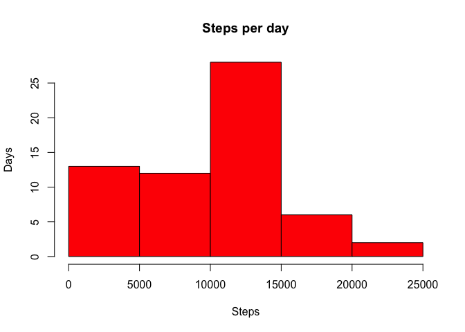

```r
## plot histogram of total steps for each day
hist(total_steps$total.steps, xlab = "Steps", ylab = "Days", main = "Steps per day", col = "red")
```

- **Calculate and report the mean and median of the total number of steps taken per day**.

```r
ave_steps <- mean(total_steps$total.steps, na.rm = TRUE)
med_steps <- median(total_steps$total.steps, na.rm = TRUE)
```

The mean total number of steps taken per day: **9354.2295082**.

The median total number of steps taken per day: **10395**.

## What is the average daily activity pattern?

- **Make a time series plot (i.e. type = “l”) of the 5-minute interval (x-axis) and the average number of steps taken, averaged across all days (y-axis)**.

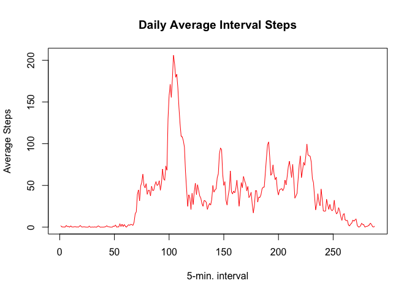

```r
intv_groupData <- group_by(groupData, interval)
ave_intv_steps <- summarise(intv_groupData, mean(steps, na.rm = TRUE))
names(ave_intv_steps) = c("interval", "ave.steps")
plot(c(1:length(ave_intv_steps$interval)), ave_intv_steps$ave.steps, type = "l", xlab = "5-min. interval", ylab = "Average Steps", main = "Daily Average Interval Steps", col = "red")
```

- **Which 5-minute interval, on average across all the days in the dataset, contains the maximum number of steps?**

```r
indx <- which(ave_intv_steps$ave.steps == max(ave_intv_steps$ave.steps))
max_intv <- ave_intv_steps[indx, 1]
```

```r
indx
```

```
## [1] 104
```

```r
max_intv
```

```
## Source: local data frame [1 x 1]
##
##   interval
##      (int)
## 1      835
```

The **104**th 5-minutes interval which is **835** contains the maximum number of steps.

## Imputing missing values

- **Calculate and report the total number of missing values in the dataset (i.e. the total number of rows with NAs).**

```r
missing_count <- sum(!complete.cases(intv_groupData))
missing_count
```

```
## [1] 2304
```

There are **2304** missing values in the dataset.

- **Create a new dataset that is equal to the original dataset but with the missing data filled in.**
- **Use the mean/median for that day, or the mean for that 5-minute interval to fill in all of the missing values in the dataset.**

```r
newData <- groupData
intv_newData <- group_by(newData, interval)
ave_intv_newSteps <- summarise(intv_newData, mean(steps, na.rm = TRUE))
names(ave_intv_newSteps) = c("interval", "ave.steps")
fill_steps <- function(inter) {
        return(ave_intv_newSteps[ave_intv_newSteps$interval == inter, ]$ave.steps)
}

newData[is.na(newData$steps), "steps"] <- sapply(newData[is.na(newData$steps), ]$interval, fill_steps)
missing_count1 <- sum(!complete.cases(newData))
missing_count1
```

```
## [1] 0
```

There are **0** missing value in the new dataset newData.

- **Make a histogram of the total number of steps taken each day and Calculate and report the mean and median total number of steps taken per day.**

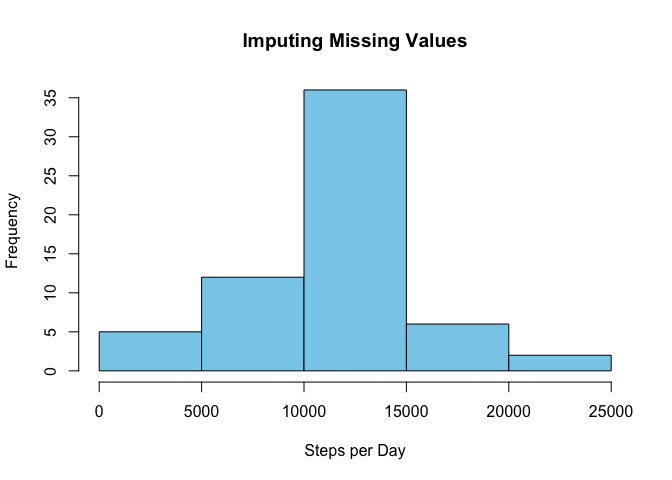

```r
day_newData <- group_by(newData, date)
total_day_steps <- summarize(day_newData, sum(steps))
names(total_day_steps) = c("date", "total.steps")
hist(total_day_steps$total.steps, xlab = "Steps per Day", main = "Imputing Missing Values", col = "skyblue")
```

```r
ave_new_steps <- mean(total_day_steps$total.steps, na.rm = TRUE)
med_new_steps <- median(total_day_steps$total.steps, na.rm = TRUE)
```

```r
ave_new_steps
```

```
## [1] 10766.19
```

```r
med_new_steps
```

```
## [1] 10766.19
```

## Are there differences in activity patterns between weekdays and weekends?

- **Create a new factor variable in the dataset with two levels – “weekday” and “weekend” indicating whether a given date is a weekday or weekend day.**

```r
week_data <- ifelse(weekdays(as.Date(newData$date), abbreviate = T) %in% c("Sat", "Sun"), "weekend", "weekday")
#mutate(newData, day = week_data)
newData$day <- week_data
#week_data <- weekdays(as.Date(newData$data), abbreviate = T)
#for (i in 1:length(week_data)) {
#        if (week_data[i] == "Sat" | week_data[i] == "Sun") {
#                     week_data[i] = "weekend"
#             } else {
#                     week_data[i] = "weekday"
#             }
#}
#
#newData$day <- week_data
```

- **Make a panel plot containing a time series plot (i.e. type = “l”) of the 5-minute interval (x-axis) and the average number of steps taken, averaged across all weekday days or weekend days (y-axis).**

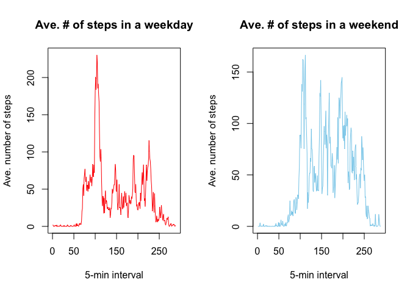

```r
weekday_data <- filter(newData, day == "weekday")
intv_weekday_data <- group_by(weekday_data, interval)
ave_intv_weekday_data <- summarise(intv_weekday_data, mean(steps, na.rm = TRUE))
names(ave_intv_weekday_data) = c("interval", "ave.steps")

weekend_data <- filter(newData, day == "weekend")
intv_weekend_data <- group_by(weekend_data, interval)
ave_intv_weekend_data <- summarise(intv_weekend_data, mean(steps, na.rm = TRUE))
names(ave_intv_weekend_data) = c("interval", "ave.steps")

par(mfrow = c(1, 2))
plot(1:length(ave_intv_weekday_data$interval), ave_intv_weekday_data$ave.steps, type = "l", xlab = "5-min interval", ylab = "Ave. number of steps", main = "Ave. # of steps in a weekday", col = "red")

plot(1:length(ave_intv_weekend_data$interval), ave_intv_weekend_data$ave.steps, type = "l", xlab = "5-min interval", ylab = "Ave. number of steps", main = "Ave. # of steps in a weekend", col = "skyblue")
```